# HW3

Diego Lozoya | 745345

2025-02-04

# Librerías

```r
library(quantmod)
```

# Activos seleccionado

- JPMorgan Chase & Co. (JPM)
- Costco Wholesale Corporation (COST)
- Microsoft Corporation (MSFT)

# JPM

## Hecho estilizado 1:

```r
datos <- new.env()
ticker <- "JPM"
getSymbols(ticker, env=datos)
```

```
## [1] "JPM"
```

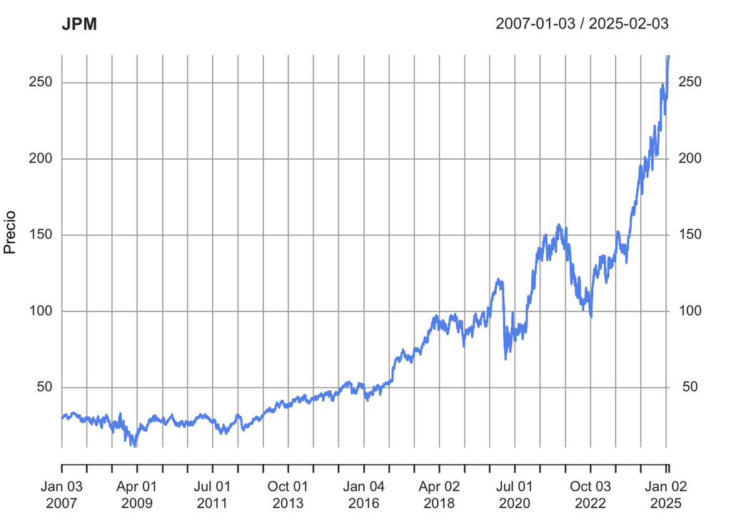

```r
precio <- datos[[ticker]][,6]

plot(precio, type="l", ylab="Precio", col="cornflowerblue", main=ticker)
```

El comportamiento observado corresponde al comportamiento de una caminata aleatoria, ya que no hay una tendencia clara sobre lo que puede suceder y el precio flucúa de manera libre en el tiempo. Se puede observar que al largo plazo hay una tendencia positiva, sin embargo, en el corto plazo esto es impredecible.

## Hecho estilizado 2:

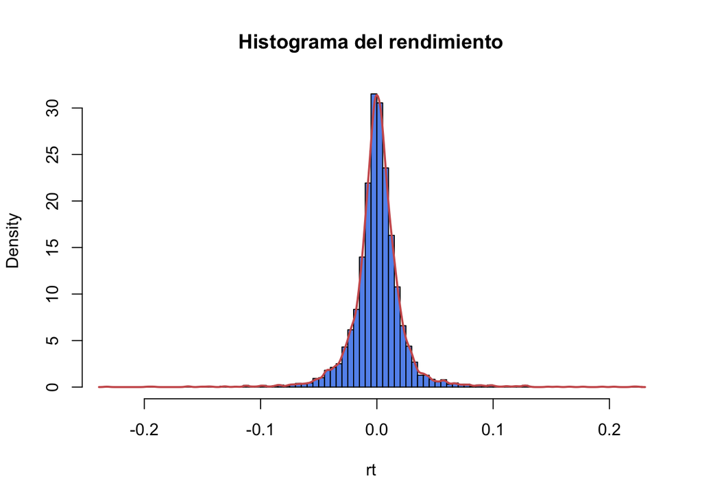

```r
rt <- na.omit(diff(log(precio)))
hist(rt, n=100, col="cornflowerblue", main="Histograma del rendimiento", prob=TRUE)
lines(density(rt), col="indianred", lwd=2)
```

La distribución del rendimiento del precio tiene una forma aproximadamente “acampanada”. Se puede apreciar que la media de los datos se acomoda al rededor del 0.

## Hecho estilizado 3:

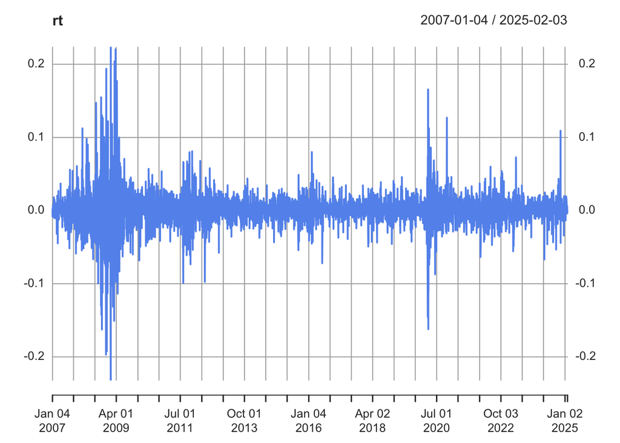

```r
plot(rt, col="cornflowerblue")
```

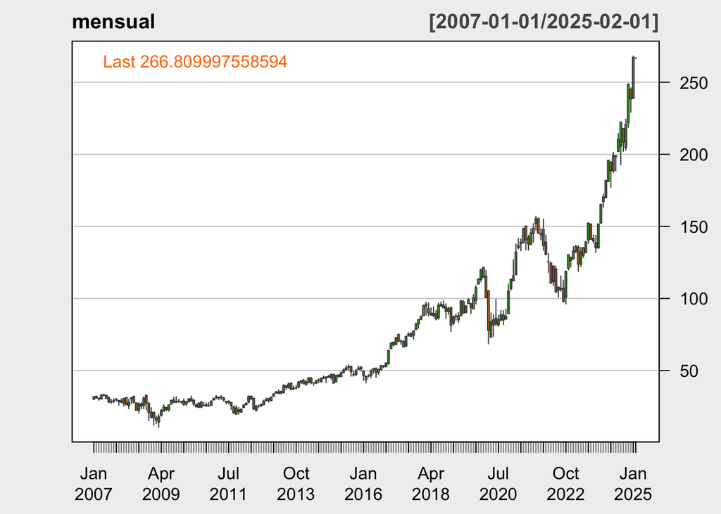

```r
mensual <- to.monthly(precio)
chartSeries(mensual, theme="white", main=ticker)
```

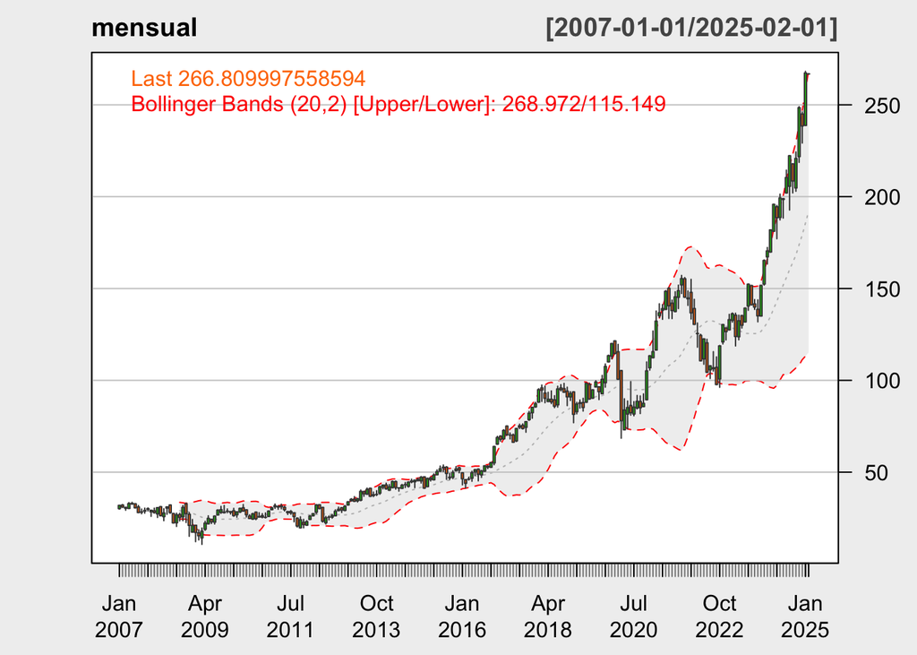

```r
addBBands()
```

Los rendimientos de los activos presentan volatilidad no constante y agrupada.

## Hecho estilizado 4:

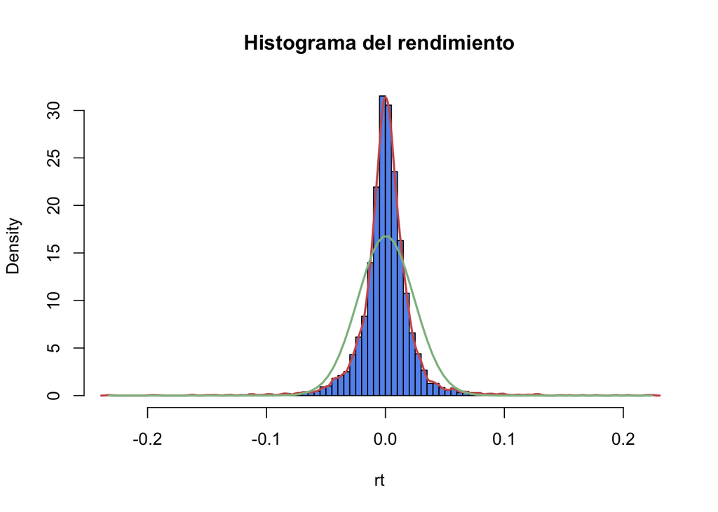

```r
rt <- na.omit(diff(log(precio)))
hist(rt, n=100, col="cornflowerblue", main="Histograma del rendimiento", prob=TRUE)
lines(density(rt), col="indianred", lwd=2)
xval <- seq(min(rt), max(rt), length.out=100)
lines(xval, dnorm(xval, mean=mean(rt), sd=sd(rt)), col="darkseagreen", lwd=2)
```

La distribución de los rendimientos presenta leptocurtosis, es decir que hay una mayor agrupación de datos en la media, lo que produce que no sea exactamente normalmente distribuida.

# COST

## Hecho estilizado 1:

```r
datos <- new.env()
ticker <- "COST"
getSymbols(ticker, env=datos)
```

```
## [1] "COST"
```

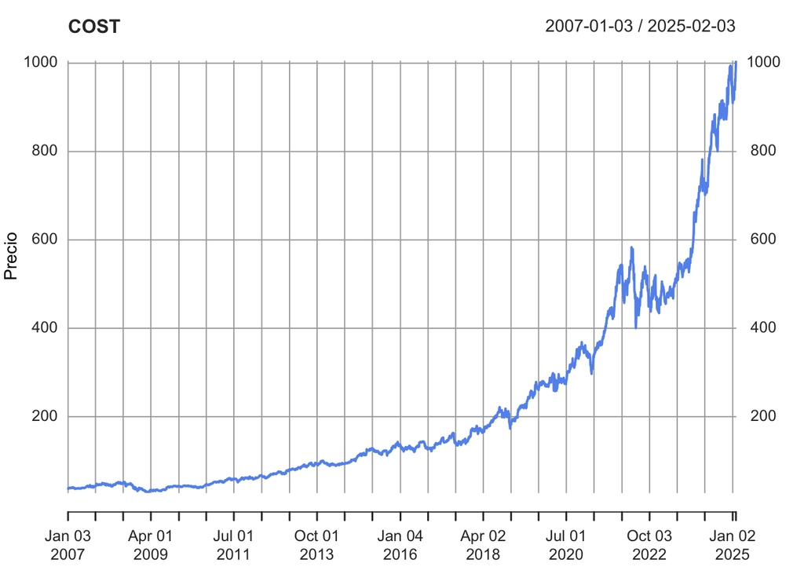

```r
precio <- datos[[ticker]][,6]

plot(precio, type="l", ylab="Precio", col="cornflowerblue", main=ticker)
```

El comportamiento observado corresponde al comportamiento de una caminata aleatoria, ya que no hay una tendencia clara sobre lo que puede suceder y el precio flucúa de manera libre en el tiempo. Se puede observar que al largo plazo hay una tendencia positiva, sin embargo, en el corto plazo esto es impredecible.

## Hecho estilizado 2:

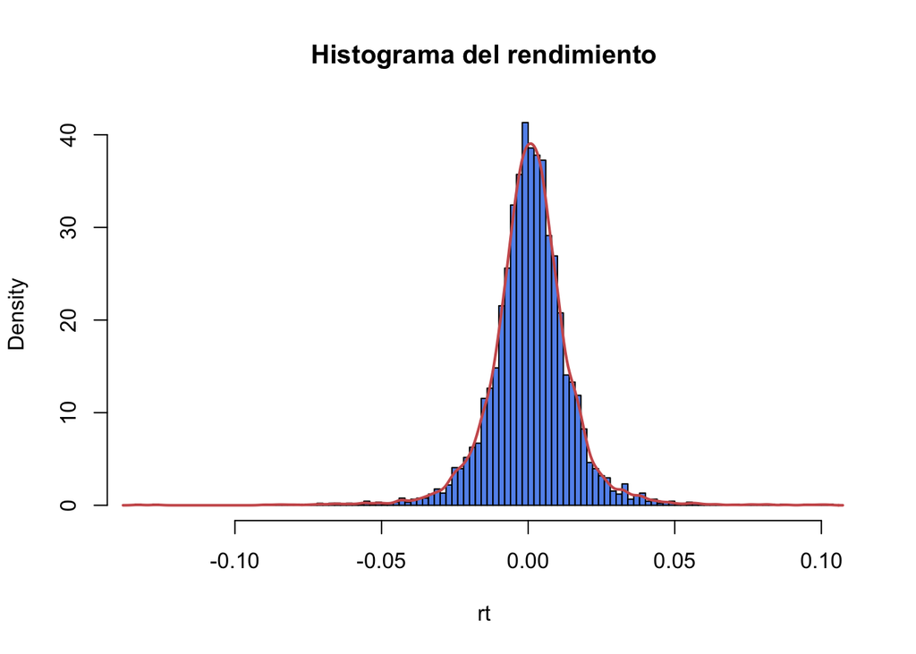

```r
rt <- na.omit(diff(log(precio)))
hist(rt, n=100, col="cornflowerblue", main="Histograma del rendimiento", prob=TRUE)
lines(density(rt), col="indianred", lwd=2)
```

La distribución del rendimiento del precio tiene una forma aproximadamente “acampanada”. Se puede apreciar que la media de los datos se acomoda al rededor del 0.

## Hecho estilizado 3:

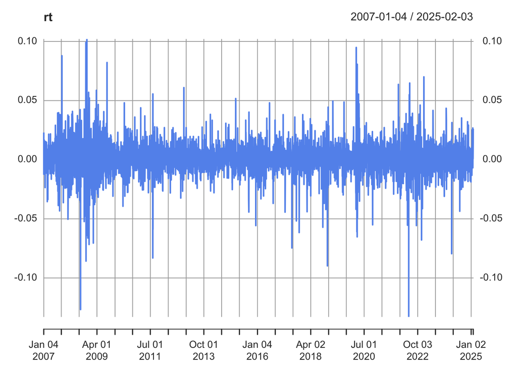

```r
plot(rt, col="cornflowerblue")
```

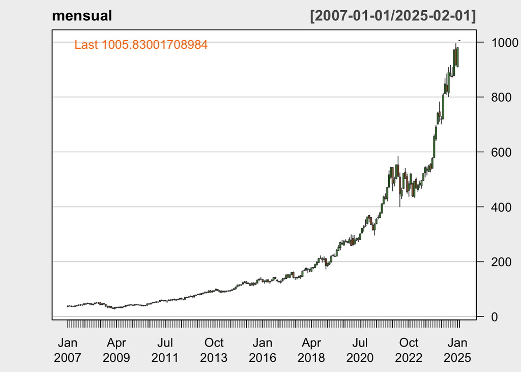

```r
mensual <- to.monthly(precio)
chartSeries(mensual, theme="white", main=ticker)
```

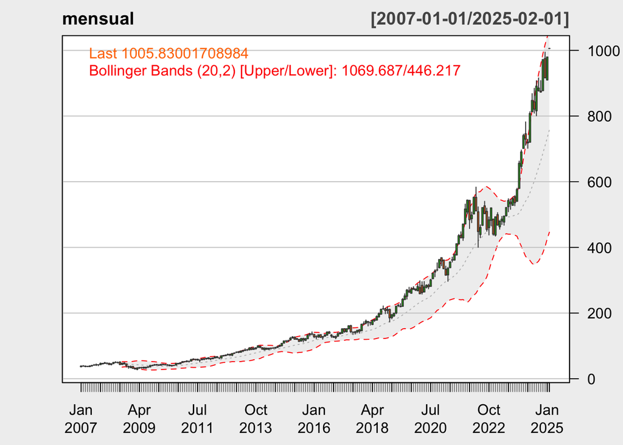

```r
addBBands()
```

Los rendimientos de los activos presentan volatilidad no constante y agrupada.

## Hecho estilizado 4:

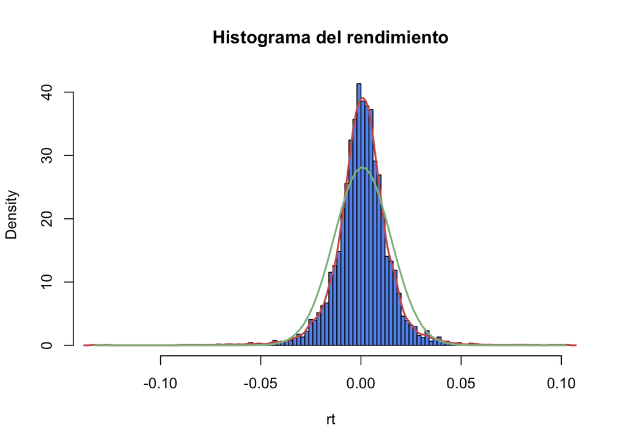

```r
rt <- na.omit(diff(log(precio)))
hist(rt, n=100, col="cornflowerblue", main="Histograma del rendimiento", prob=TRUE)
lines(density(rt), col="indianred", lwd=2)
xval <- seq(min(rt), max(rt), length.out=100)
lines(xval, dnorm(xval, mean=mean(rt), sd=sd(rt)), col="darkseagreen", lwd=2)
```

La distribución de los rendimientos presenta leptocurtosis, es decir que hay una mayor agrupación de datos en la media, lo que produce que no sea exactamente normalmente distribuida.

# MSFT

## Hecho estilizado 1:

```r
datos <- new.env()
ticker <- "MSFT"
getSymbols(ticker, env=datos)
```

```
## [1] "MSFT"
```

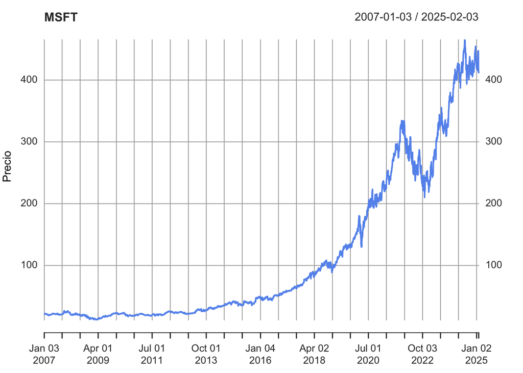

```r
precio <- datos[[ticker]][,6]

plot(precio, type="l", ylab="Precio", col="cornflowerblue", main=ticker)
```

El comportamiento observado corresponde al comportamiento de una caminata aleatoria, ya que no hay una tendencia clara sobre lo que puede suceder y el precio flucúa de manera libre en el tiempo. Se puede observar que al largo plazo hay una tendencia positiva, sin embargo, en el corto plazo esto es impredecible.

## Hecho estilizado 2:

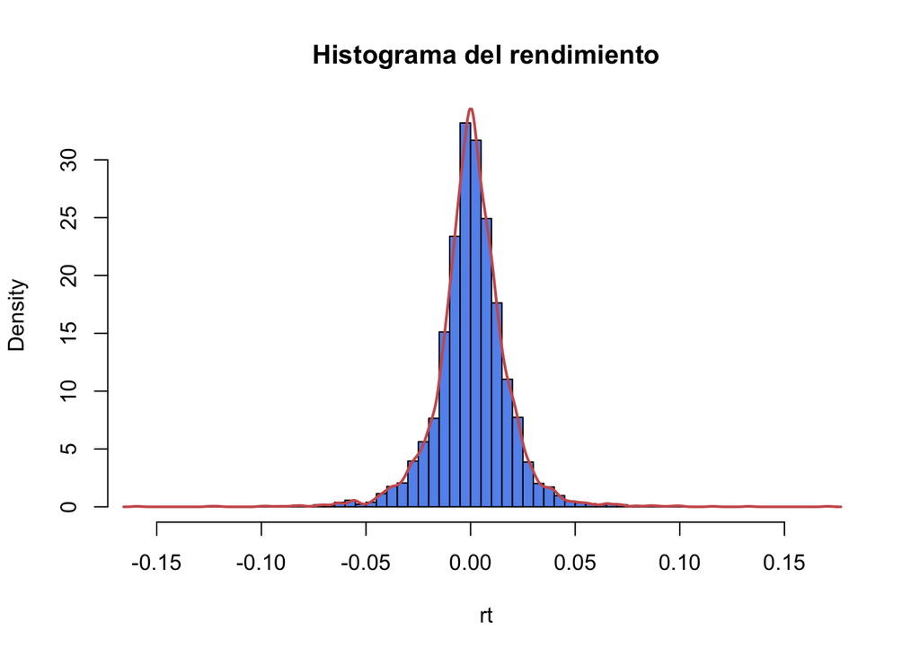

```r
rt <- na.omit(diff(log(precio)))
hist(rt, n=100, col="cornflowerblue", main="Histograma del rendimiento", prob=TRUE)
lines(density(rt), col="indianred", lwd=2)
```

La distribución del rendimiento del precio tiene una forma aproximadamente “acampanada”. Se puede apreciar que la media de los datos se acomoda al rededor del 0.

## Hecho estilizado 3:

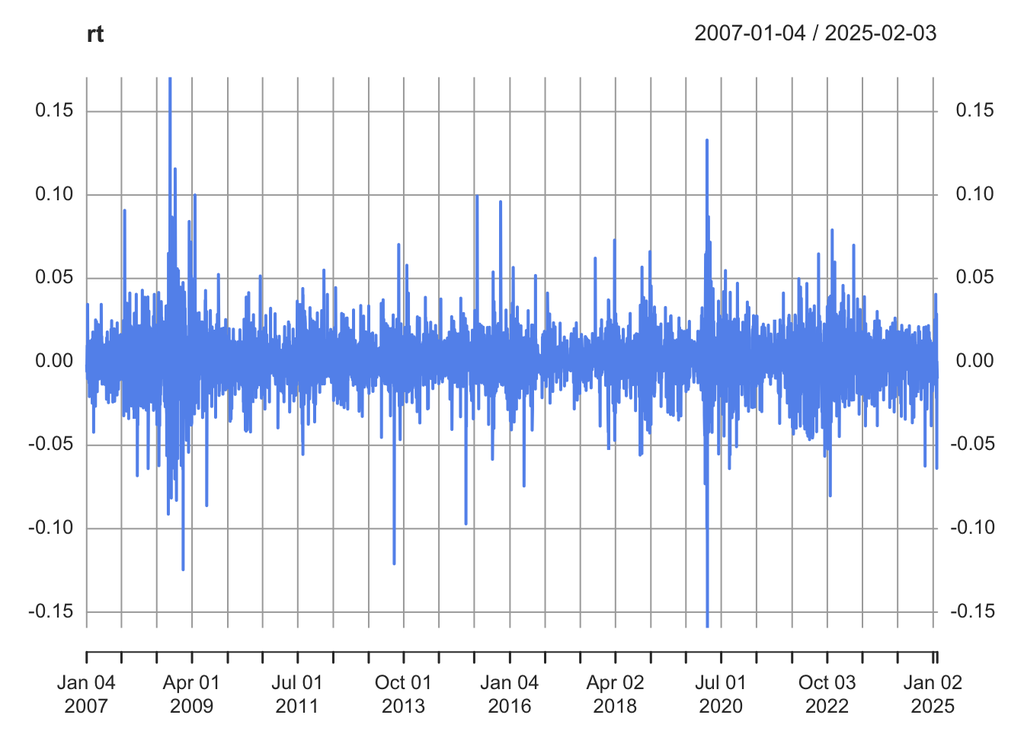

```r
plot(rt, col="cornflowerblue")
```

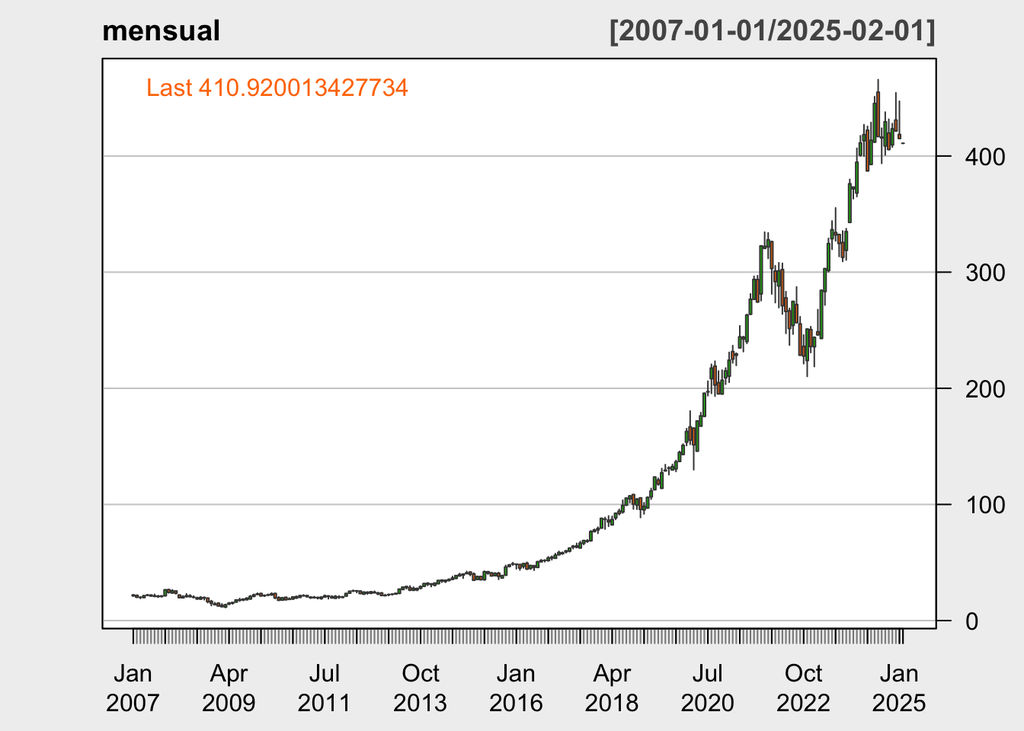

```r
mensual <- to.monthly(precio)
chartSeries(mensual, theme="white", main=ticker)
```

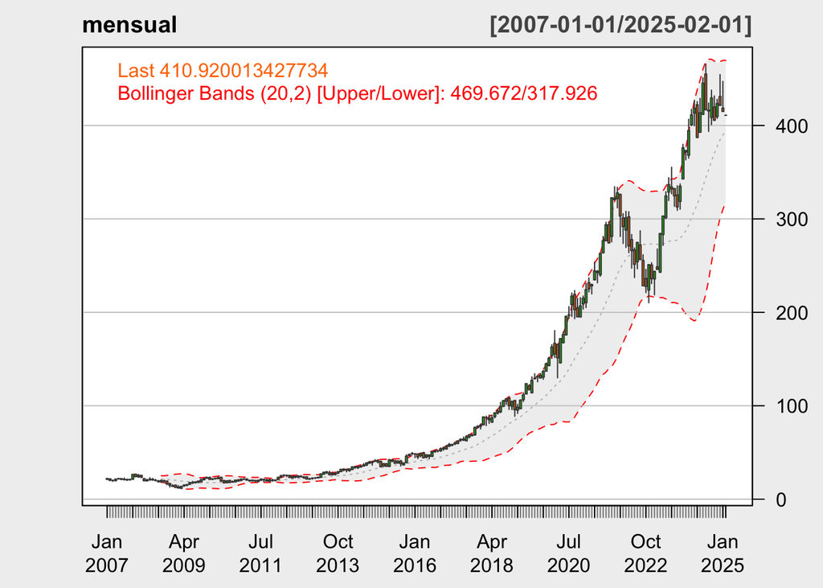

```r
addBBands()
```

Los rendimientos de los activos presentan volatilidad no constante y agrupada.

## Hecho estilizado 4:

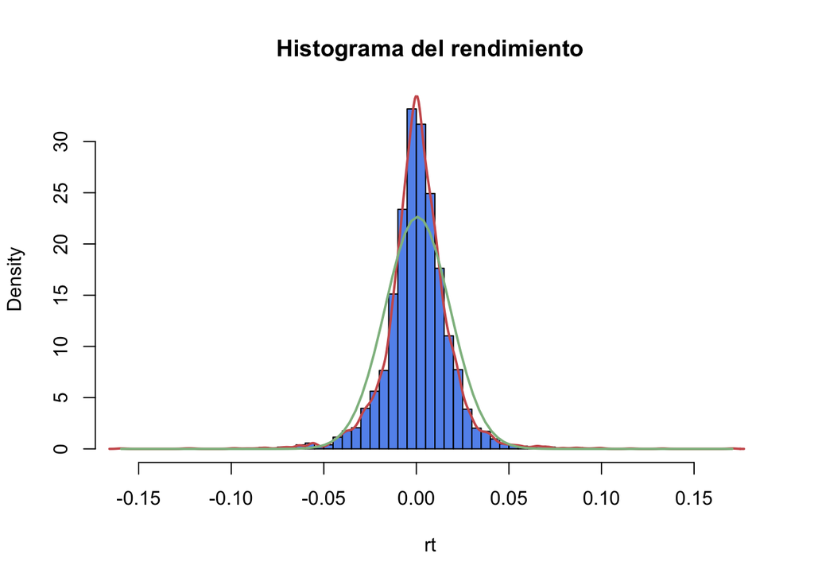

```r
rt <- na.omit(diff(log(precio)))
hist(rt, n=100, col="cornflowerblue", main="Histograma del rendimiento", prob=TRUE)
lines(density(rt), col="indianred", lwd=2)
xval <- seq(min(rt), max(rt), length.out=100)
lines(xval, dnorm(xval, mean=mean(rt), sd=sd(rt)), col="darkseagreen", lwd=2)
```

La distribución de los rendimientos presenta leptocurtosis, es decir que hay una mayor agrupación de datos en la media, lo que produce que no sea exactamente normalmente distribuida.

# Conclusión

Con base en el análisis hecho de estor tres activos que cotizan en la bolsa estadounidense, más haber análizado un activo que cotiza en la BMV, es adecuado decir que todos los activos que cotizan en alguna bolsa cumplen con los 4 hechos estilizados, los cuales son:

- **1):** Los precios de los activos y el valor de los portafolios siguen una caminata aleatoria.
- **2):** La distribución del rendimiento del precio tiene una forma aproximadamente “acampanada”.
- **3):** Los rendimientos de los activos presentan volatilidad no constante y agrupada.
- **4):** La distribución de los rendimientos presenta leptocurtosis.